# Coursework Report

*N* removed NAs: 3

*N* removed typo: 1

*N* removed <18: 14

*N* total clean: 133

| Group | *N* | *M*<sub>age</sub> | *M*<sub>rating</sub> |
| --- | --- | --- | --- |
| Control | 66 | 21.12 | 6.16 |
| Experim | 67 | 21.12 | 5.48 |

**Main analysis results**

*t*(131) = 4.8, *p* < .001

[interactive chart not shown]

[figure not shown]

[interactive chart not shown]

# Coursework Report

Analysing Data, Spring 2020

This student has a record of specific learning difficulty (dyslexia/dyspraxia). Please mark this report in accordance with the [marking guidelines for SLD](https://www.sussex.ac.uk/studentsupport/staff/spld?fbclid=IwAR2lYKD6xvuv9egQDvG8d_oed9GUD3KXQn3gAdlHZ1gQB8gDddBdeOEmKdE).

# Methods

## Participants

Table 1 *Descriptive statistics by Condition*

[output not shown]

## Design

The research question being considered in this report is whether the results of the red effect in the original study of Elliot et al (2010) are replicable. The independent categorical variable is the background colour of the picture presented to the participants. It is also the predictor. It has two levels, either the factor red or white. The dependent continuous variable in the study is the perceived attractiveness of the man in the picture. This was investigated using 3 questions. Firstly, “How attractive do you think this person is?”, secondly, “How pleasant is this person to look at?” and lastly, “If I were to meet this person face to face, I would think he is attractive”. The participants were then asked to answer using a 9-point scale such that a low score such as 1 would indicate finding the man not attractive all and 9 finding him extremely attractive. All 3 scores from each participants were then averaged to acquire a composite index. The hypothesis of this study is that women, when presented with the picture of the man on a red background will be more likely to rate him a higher score out of 9 for perceived attractiveness on average than women presented with the man on a white background who will rate him lower on the scale. This statement will be tested using a T-test statistical analysis.

# Results

Table 2 *Mean Scores Grouped by Condition*

| Condition | *M*<sub>Score</sub> | *SD*<sub>Score</sub> |
| --- | --- | --- |
| Control | 6.16 | 0.86 |
| Experimental | 5.49 | 0.77 |

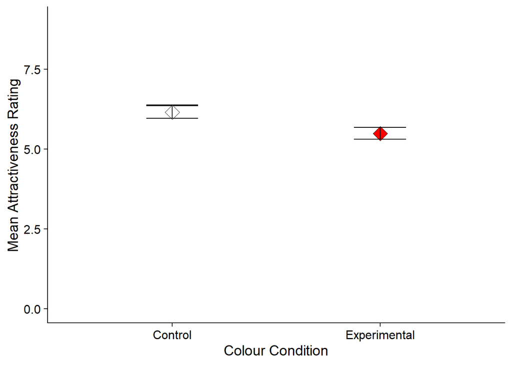